# Shinkansen Bullet Train Passenger Satisfaction – Predictive Analysis

1. Imports & Setup

```python
import pandas as pd
import numpy as np

import matplotlib.pyplot as plt
import seaborn as sns

# Scikit-learn Preprocessing & Model Selection
from sklearn.model_selection import train_test_split, GridSearchCV, RandomizedSearchCV
from sklearn.preprocessing import LabelEncoder, StandardScaler
from sklearn.impute import KNNImputer

# Scikit-learn Models & Metrics
from sklearn.ensemble import (
    RandomForestClassifier,
    AdaBoostClassifier,
    GradientBoostingClassifier
)
from sklearn.linear_model import LogisticRegression
from sklearn.tree import DecisionTreeClassifier, plot_tree
from sklearn.svm import SVC

from sklearn.metrics import (
    accuracy_score,
    classification_report,
    confusion_matrix,
    precision_score,
    recall_score,
    f1_score,
    roc_auc_score
)

# TensorFlow / Keras (for Neural Network)
import tensorflow as tf
from tensorflow.keras.models import Sequential
from tensorflow.keras.layers import Dense, Dropout

# Plotting Preferences (optional, can comment out if you prefer default)
plt.rcParams['figure.figsize'] = (8, 6)
sns.set_style('whitegrid')

# Set a random seed for reproducibility
RSEED = 28
np.random.seed(RSEED)
tf.random.set_seed(RSEED)
```

2. Data Loading

Problem Context:

We have two separate datasets:

- one with travel details (Traveldata_train.csv) and another with survey responses (Surveydata_train.csv).
- We'll merge them on the 'ID' column to form a single training dataset.
- Similarly, there's a test dataset (travel_data_test & survey_data_test), which we'll merge for predictions.
- Our target is 'Overall_Experience' (1 => Satisfied, 0 => Not Satisfied).

```python
# Load the training datasets
travel_data = pd.read_csv('Traveldata_train.csv')
survey_data = pd.read_csv('Surveydata_train.csv')

# Merge training data on ID
train_df = pd.merge(travel_data, survey_data, on='ID')

# Load the test datasets
travel_data_test = pd.read_csv('Traveldata_test.csv')
survey_data_test = pd.read_csv('Surveydata_test.csv')

# Merge test data on ID
test_df = pd.merge(travel_data_test, survey_data_test, on='ID')

# Make a copy of test_df for final submission reference
test_copy = test_df.copy()

print("Training Data Shape:", train_df.shape)
print("Test Data Shape:", test_df.shape)
```

```
Training Data Shape: (94379, 25)
Test Data Shape: (35602, 24)
```

3. Quick EDA & Data Checks

```python
print("\nSample of Merged Training Data:")
display(train_df.head())

print("\nNull Values in Training Data:")
display(train_df.isnull().sum())

print("\nUnique Values in Each Column (Training Data):")
display(train_df.nunique())
```

```
Sample of Merged Training Data:
```

|  | ID | Gender | Customer_Type | Age | Type_Travel | Travel_Class | Travel_Distance | Departure_Delay_in_Mins | Arrival_Delay_in_Mins | Overall_Experience | ... | Onboard_Wifi_Service | Onboard_Entertainment | Online_Support | Ease_of_Online_Booking | Onboard_Service | Legroom | Baggage_Handling | CheckIn_Service | Cleanliness | Online_Boarding |
| --- | --- | --- | --- | --- | --- | --- | --- | --- | --- | --- | --- | --- | --- | --- | --- | --- | --- | --- | --- | --- | --- |
| 0 | 98800001 | Female | Loyal Customer | 52.0 | NaN | Business | 272 | 0.0 | 5.0 | 0 | ... | Good | Needs Improvement | Acceptable | Needs Improvement | Needs Improvement | Acceptable | Needs Improvement | Good | Needs Improvement | Poor |
| 1 | 98800002 | Male | Loyal Customer | 48.0 | Personal Travel | Eco | 2200 | 9.0 | 0.0 | 0 | ... | Good | Poor | Good | Good | Excellent | Needs Improvement | Poor | Needs Improvement | Good | Good |
| 2 | 98800003 | Female | Loyal Customer | 43.0 | Business Travel | Business | 1061 | 77.0 | 119.0 | 1 | ... | Needs Improvement | Good | Excellent | Excellent | Excellent | Excellent | Excellent | Good | Excellent | Excellent |
| 3 | 98800004 | Female | Loyal Customer | 44.0 | Business Travel | Business | 780 | 13.0 | 18.0 | 0 | ... | Acceptable | Needs Improvement | Acceptable | Acceptable | Acceptable | Acceptable | Acceptable | Good | Acceptable | Acceptable |
| 4 | 98800005 | Female | Loyal Customer | 50.0 | Business Travel | Business | 1981 | 0.0 | 0.0 | 1 | ... | Needs Improvement | Good | Excellent | Good | Good | Good | Good | Good | Good | Good |

5 rows × 25 columns

```
Null Values in Training Data:
```

```
ID                            0
Gender                       77
Customer_Type              8951
Age                          33
Type_Travel                9226
Travel_Class                  0
Travel_Distance               0
Departure_Delay_in_Mins      57
Arrival_Delay_in_Mins       357
Overall_Experience            0
Seat_Comfort                 61
Seat_Class                    0
Arrival_Time_Convenient    8930
Catering                   8741
Platform_Location            30
Onboard_Wifi_Service         30
Onboard_Entertainment        18
Online_Support               91
Ease_of_Online_Booking       73
Onboard_Service            7601
Legroom                      90
Baggage_Handling            142
CheckIn_Service              77
Cleanliness                   6
Online_Boarding               6
dtype: int64
```

```
Unique Values in Each Column (Training Data):
```

```
ID                         94379
Gender                         2
Customer_Type                  2
Age                           75
Type_Travel                    2
Travel_Class                   2
Travel_Distance             5210
Departure_Delay_in_Mins      437
Arrival_Delay_in_Mins        434
Overall_Experience             2
Seat_Comfort                   6
Seat_Class                     2
Arrival_Time_Convenient        6
Catering                       6
Platform_Location              6
Onboard_Wifi_Service           6
Onboard_Entertainment          6
Online_Support                 6
Ease_of_Online_Booking         6
Onboard_Service                6
Legroom                        6
Baggage_Handling               5
CheckIn_Service                6
Cleanliness                    6
Online_Boarding                6
dtype: int64
```

4. Data Cleaning

We see some columns may have null values. Instead of dropping rows with missing values, we'll impute them. We'll demonstrate one approach:

1. For numeric features, we can use a KNNImputer or fill with median.
2. For categorical features, we fill with mode.

Below, we'll do a simple random fill for demonstration, but a more robust approach is recommended (like KNNImputer). We'll apply the same to test data.

Simple Random Fill Imputation for Demonstration

```python
# For each column, fill nulls with a random selection from existing (non-null) distribution
for column in train_df.columns:
    # Distribution of non-null values in that column
    distribution = train_df[column].value_counts(normalize=True)
    # Number of null values
    num_nulls = train_df[column].isnull().sum()
    if num_nulls > 0:
        # Random choice from existing categories based on distribution
        random_sample = np.random.choice(distribution.index,
                                         size=num_nulls,
                                         p=distribution.values)
        # Fill the null values
        train_df.loc[train_df[column].isnull(), column] = random_sample

print("\nNull Values After Imputation (Training):")
display(train_df.isnull().sum())
```

```
Null Values After Imputation (Training):
```

```
ID                         0
Gender                     0
Customer_Type              0
Age                        0
Type_Travel                0
Travel_Class               0
Travel_Distance            0
Departure_Delay_in_Mins    0
Arrival_Delay_in_Mins      0
Overall_Experience         0
Seat_Comfort               0
Seat_Class                 0
Arrival_Time_Convenient    0
Catering                   0
Platform_Location          0
Onboard_Wifi_Service       0
Onboard_Entertainment      0
Online_Support             0
Ease_of_Online_Booking     0
Onboard_Service            0
Legroom                    0
Baggage_Handling           0
CheckIn_Service            0
Cleanliness                0
Online_Boarding            0
dtype: int64
```

Apply same approach to Test Data

```python
for column in test_df.columns:
    distribution = test_df[column].value_counts(normalize=True)
    num_nulls = test_df[column].isnull().sum()
    if num_nulls > 0:
        random_sample = np.random.choice(distribution.index,
                                         size=num_nulls,
                                         p=distribution.values)
        test_df.loc[test_df[column].isnull(), column] = random_sample

print("\nNull Values After Imputation (Test):")
display(test_df.isnull().sum())
```

```
Null Values After Imputation (Test):
```

```
ID                         0
Gender                     0
Customer_Type              0
Age                        0
Type_Travel                0
Travel_Class               0
Travel_Distance            0
Departure_Delay_in_Mins    0
Arrival_Delay_in_Mins      0
Seat_Comfort               0
Seat_Class                 0
Arrival_Time_Convenient    0
Catering                   0
Platform_Location          0
Onboard_Wifi_Service       0
Onboard_Entertainment      0
Online_Support             0
Ease_of_Online_Booking     0
Onboard_Service            0
Legroom                    0
Baggage_Handling           0
CheckIn_Service            0
Cleanliness                0
Online_Boarding            0
dtype: int64
```

5. Exploratory Data Analysis

Let's do some quick EDA to understand the distribution of 'Overall_Experience' and some other features. We'll explore the relationship of Overall_Experience with travel-related attributes like Travel_Class or Delay times.

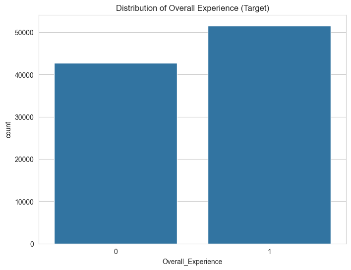

```
Overall Experience Counts:
```

```
Overall_Experience
1    51593
0    42786
Name: count, dtype: int64
```

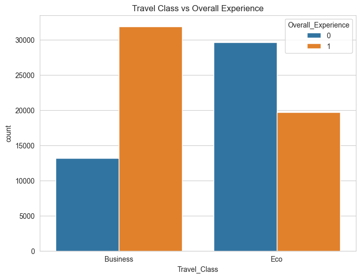

```python
# Distribution of target
sns.countplot(x='Overall_Experience', data=train_df)
plt.title("Distribution of Overall Experience (Target)")
plt.show()

print("\nOverall Experience Counts:")
display(train_df['Overall_Experience'].value_counts())

# Example: Checking how Travel_Class correlates with Overall_Experience
# (If the data is strictly numeric, we might need to label-encode first,
# but let's see if it's already categorical.)
if train_df['Travel_Class'].dtype == 'object':
    plt.figure()
    sns.countplot(x='Travel_Class', hue='Overall_Experience', data=train_df)
    plt.title("Travel Class vs Overall Experience")
    plt.show()
```

In a more thorough EDA, we'd create correlation plots, look at distribution of numeric columns, check outliers, etc.

6. Feature Preparation

Separate Features & Target

```python
X = train_df.drop('Overall_Experience', axis=1)
y = train_df['Overall_Experience']
# We'll preserve ID in test data so we can submit predictions with IDs
test_ids = test_df['ID'].values
X_test_final = test_df.drop('ID', axis=1)  # We'll need this for final prediction
```

Convert All to Numeric

```python
# If we have object columns, let's label encode them.
# Alternatively, we might do one-hot, but for a quick approach LabelEncoder is fine.
le = LabelEncoder()

for col in X.columns:
    if X[col].dtype == 'object':
        X[col] = le.fit_transform(X[col].astype(str))

for col in X_test_final.columns:
    if X_test_final[col].dtype == 'object':
        X_test_final[col] = le.fit_transform(X_test_final[col].astype(str))

# ----------------- Train-Val Split for Model Evaluation ----------------- #
X_train, X_val, y_train, y_val = train_test_split(
    X.drop('ID', axis=1),  # drop ID to avoid it as a feature
    y,
    test_size=0.2,
    random_state=RSEED
)
```

7. Model Evaluation Function

```python
def evaluate_model_performance(model, X_tr, y_tr, X_val, y_val, model_name="Model"):
    """
    Fits the model on training data, predicts on both train and val,
    and prints classification metrics & confusion matrix.
    """
    model.fit(X_tr, y_tr)

    # Predict on training set
    y_tr_pred = model.predict(X_tr)
    # Predict on validation set
    y_val_pred = model.predict(X_val)

    print(f"\n--- {model_name} Performance ---")
    print("Training Accuracy:", accuracy_score(y_tr, y_tr_pred))
    print("Validation Accuracy:", accuracy_score(y_val, y_val_pred))

    # Classification report on validation set
    print("\nValidation Classification Report:")
    print(classification_report(y_val, y_val_pred))

    # Confusion matrix
    cm = confusion_matrix(y_val, y_val_pred)
    plt.figure()
    sns.heatmap(cm, annot=True, fmt='d', cmap='Blues',
                xticklabels=["Not Satisfied", "Satisfied"],
                yticklabels=["Not Satisfied", "Satisfied"])
    plt.title(f"{model_name} Confusion Matrix (Validation)")
    plt.ylabel('True Label')
    plt.xlabel('Predicted Label')
    plt.show()

    return model  # Return the fitted model for potential reuse
```

8. Modeling: Random Forest

We'll start with a Random Forest Classifier. We'll do a simple instance, then we can try tuning or we can do a quick RandomizedSearch for best hyperparams.

```
--- Random Forest (Default) Performance ---
Training Accuracy: 1.0
Validation Accuracy: 0.9445327399872855

Validation Classification Report:
              precision    recall  f1-score   support

           0       0.94      0.94      0.94      8554
           1       0.95      0.95      0.95     10322

    accuracy                           0.94     18876
   macro avg       0.94      0.94      0.94     18876
weighted avg       0.94      0.94      0.94     18876
```

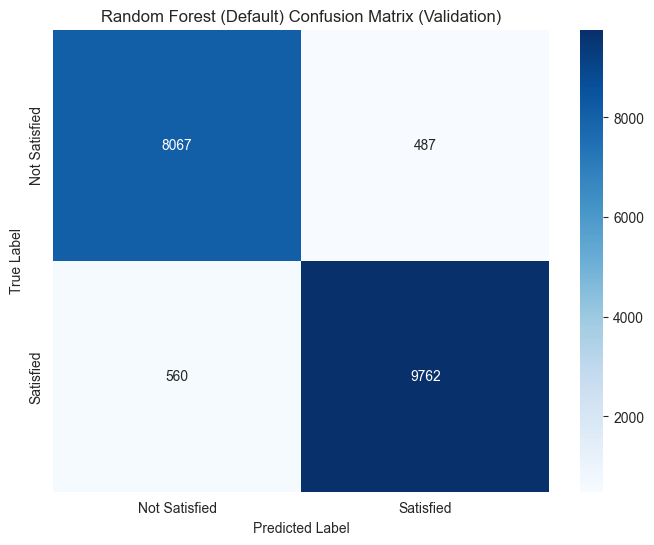

[output not shown]

```python
rf_model = RandomForestClassifier(random_state=RSEED)
rf_model = evaluate_model_performance(rf_model, X_train, y_train, X_val, y_val,
                                      model_name="Random Forest (Default)")

# If we want to do a quick hyperparameter tuning with RandomizedSearchCV:
# You can uncomment below if you'd like to try it.
"""
param_dist_rf = {
    'n_estimators': [100, 120, 150],
    'max_depth': [5, 7, 10, None],
    'min_samples_leaf': [1, 2, 5, 10],
    'max_features': ['sqrt', 0.8, 1.0],
    'class_weight': [None, 'balanced']
}
random_search_rf = RandomizedSearchCV(RandomForestClassifier(random_state=RSEED),
                                      param_dist_rf,
                                      n_iter=10,
                                      scoring='accuracy',
                                      cv=3,
                                      random_state=RSEED,
                                      n_jobs=-1)
random_search_rf.fit(X_train, y_train)
print("Best Params (Random Forest):", random_search_rf.best_params_)

best_rf = random_search_rf.best_estimator_
best_rf = evaluate_model_performance(best_rf, X_train, y_train, X_val, y_val,
                                     model_name="Random Forest (Tuned)")
"""
```

9. Modeling: AdaBoost

```
--- AdaBoost Performance ---
Training Accuracy: 0.9059375124167252
Validation Accuracy: 0.9086670904852723

Validation Classification Report:
              precision    recall  f1-score   support

           0       0.91      0.88      0.90      8554
           1       0.91      0.93      0.92     10322

    accuracy                           0.91     18876
   macro avg       0.91      0.91      0.91     18876
weighted avg       0.91      0.91      0.91     18876
```

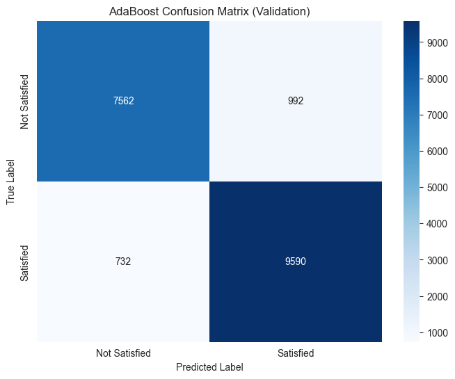

```python
ada_model = AdaBoostClassifier(
    estimator=DecisionTreeClassifier(max_depth=2),  # small trees as base
    n_estimators=200,
    learning_rate=0.1,
    random_state=RSEED
)
ada_model = evaluate_model_performance(ada_model, X_train, y_train, X_val, y_val,
                                       model_name="AdaBoost")
```

10. Modeling: Gradient Boosting

```
--- Gradient Boosting Performance ---
Training Accuracy: 0.9309431413321325
Validation Accuracy: 0.9306526806526807

Validation Classification Report:
              precision    recall  f1-score   support

           0       0.93      0.92      0.92      8554
           1       0.94      0.94      0.94     10322

    accuracy                           0.93     18876
   macro avg       0.93      0.93      0.93     18876
weighted avg       0.93      0.93      0.93     18876
```

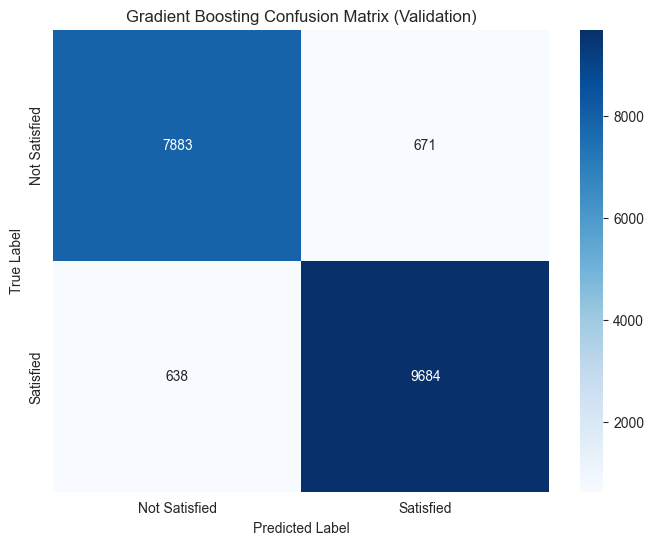

```python
gb_model = GradientBoostingClassifier(
    n_estimators=200,
    max_depth=3,
    learning_rate=0.1,
    random_state=RSEED
)
gb_model = evaluate_model_performance(gb_model, X_train, y_train, X_val, y_val,
                                      model_name="Gradient Boosting")
```

11. Modeling: SVM

```
--- SVM (Default) Performance ---
Training Accuracy: 0.5965988106432857
Validation Accuracy: 0.5964717101080738

Validation Classification Report:
              precision    recall  f1-score   support

           0       0.54      0.66      0.60      8554
           1       0.66      0.54      0.59     10322

    accuracy                           0.60     18876
   macro avg       0.60      0.60      0.60     18876
weighted avg       0.61      0.60      0.60     18876
```

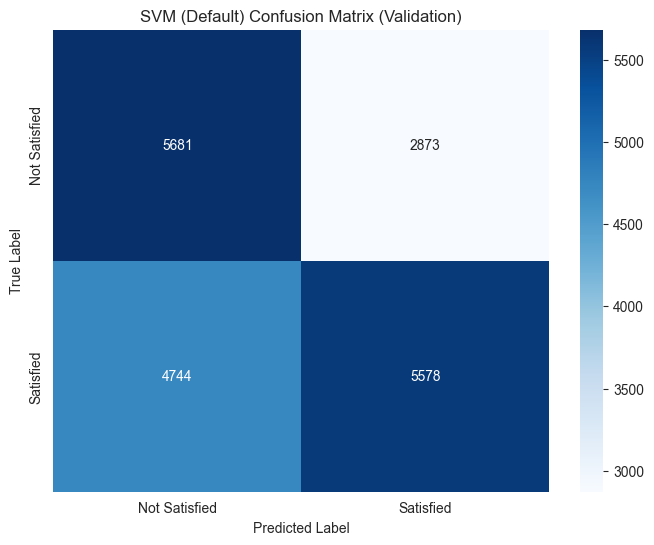

```python
svm_model = SVC(
    C=1.0,
    kernel='rbf',
    gamma='scale',
    random_state=RSEED
)
svm_model = evaluate_model_performance(svm_model, X_train, y_train, X_val, y_val,
                                       model_name="SVM (Default)")
```

12. Modeling: Neural Network

We'll build a simple neural network using Keras. We must ensure features are scaled (especially helpful for NN). We'll do a quick standard scaling for the numeric columns.

```python
# 1) Create scaled versions of X_train, X_val
scaler = StandardScaler()
X_train_scaled = scaler.fit_transform(X_train)
X_val_scaled = scaler.transform(X_val)
X_test_scaled = scaler.transform(X_test_final.drop('Overall_Experience', axis=1, errors='ignore'))
```

```python
# 2) Build a small NN
nn_model = Sequential([
    Dense(64, activation='relu', input_dim=X_train_scaled.shape[1]),
    Dense(32, activation='relu'),
    Dense(1, activation='sigmoid')  # Binary classification output
])

nn_model.compile(optimizer='adam', loss='binary_crossentropy', metrics=['accuracy'])
```

```python
# 3) Fit the model
history = nn_model.fit(
    X_train_scaled, y_train,
    validation_data=(X_val_scaled, y_val),
    epochs=10,
    batch_size=32,
    verbose=1
)
```

```
2360/2360 ━━━━━━━━━━━━━━━━━━━━ 3s 994us/step - accuracy: 0.8074 - loss: 0.4129 - val_accuracy: 0.8929 - val_loss: 0.2544
2360/2360 ━━━━━━━━━━━━━━━━━━━━ 2s 931us/step - accuracy: 0.9045 - loss: 0.2332 - val_accuracy: 0.9159 - val_loss: 0.2024
2360/2360 ━━━━━━━━━━━━━━━━━━━━ 2s 928us/step - accuracy: 0.9190 - loss: 0.1929 - val_accuracy: 0.9238 - val_loss: 0.1852
2360/2360 ━━━━━━━━━━━━━━━━━━━━ 2s 914us/step - accuracy: 0.9247 - loss: 0.1783 - val_accuracy: 0.9274 - val_loss: 0.1773
2360/2360 ━━━━━━━━━━━━━━━━━━━━ 2s 930us/step - accuracy: 0.9282 - loss: 0.1701 - val_accuracy: 0.9283 - val_loss: 0.1726
2360/2360 ━━━━━━━━━━━━━━━━━━━━ 2s 919us/step - accuracy: 0.9307 - loss: 0.1640 - val_accuracy: 0.9301 - val_loss: 0.1685
2360/2360 ━━━━━━━━━━━━━━━━━━━━ 2s 944us/step - accuracy: 0.9322 - loss: 0.1595 - val_accuracy: 0.9307 - val_loss: 0.1656
2360/2360 ━━━━━━━━━━━━━━━━━━━━ 2s 957us/step - accuracy: 0.9340 - loss: 0.1560 - val_accuracy: 0.9321 - val_loss: 0.1623
2360/2360 ━━━━━━━━━━━━━━━━━━━━ 2s 929us/step - accuracy: 0.9347 - loss: 0.1525 - val_accuracy: 0.9329 - val_loss: 0.1606
2360/2360 ━━━━━━━━━━━━━━━━━━━━ 2s 936us/step - accuracy: 0.9359 - loss: 0.1498 - val_accuracy: 0.9329 - val_loss: 0.1591
```

```python
# 4) Evaluate on validation
val_loss, val_acc = nn_model.evaluate(X_val_scaled, y_val)
print(f"\nNeural Network Validation Accuracy: {val_acc:.2%}")
```

```
590/590 ━━━━━━━━━━━━━━━━━━━━ 0s 662us/step - accuracy: 0.9317 - loss: 0.1581

Neural Network Validation Accuracy: 93.29%
```

```
590/590 ━━━━━━━━━━━━━━━━━━━━ 0s 450us/step
```

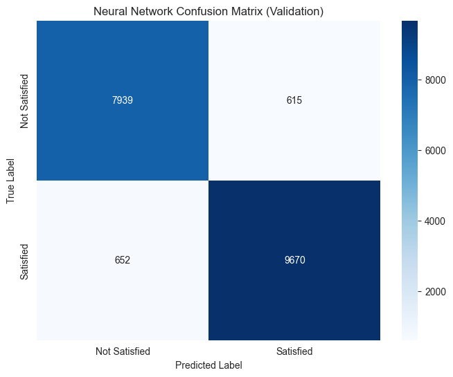

```
Classification Report (Neural Network):
              precision    recall  f1-score   support

           0       0.92      0.93      0.93      8554
           1       0.94      0.94      0.94     10322

    accuracy                           0.93     18876
   macro avg       0.93      0.93      0.93     18876
weighted avg       0.93      0.93      0.93     18876
```

```python
# Confusion matrix for NN
nn_val_preds = (nn_model.predict(X_val_scaled) >= 0.5).astype(int)
cm_nn = confusion_matrix(y_val, nn_val_preds)

plt.figure()
sns.heatmap(cm_nn, annot=True, fmt='d', cmap='Blues',
            xticklabels=["Not Satisfied", "Satisfied"],
            yticklabels=["Not Satisfied", "Satisfied"])
plt.title("Neural Network Confusion Matrix (Validation)")
plt.ylabel('True Label')
plt.xlabel('Predicted Label')
plt.show()

print("\nClassification Report (Neural Network):")
print(classification_report(y_val, nn_val_preds))
```

```python
# Let's do a quick example: Suppose AdaBoost performed best. We'll finalize it.
# We re-fit on the ENTIRE training set (X, y) to use all data for final model.
ada_final = AdaBoostClassifier(
    estimator=DecisionTreeClassifier(max_depth=2),
    n_estimators=200,
    learning_rate=0.1,
    random_state=RSEED
)
# Must label encode & drop 'ID' from X for entire training
full_X = train_df.drop(['Overall_Experience','ID'], axis=1)
for col in full_X.columns:
    if full_X[col].dtype == 'object':
        full_X[col] = le.fit_transform(full_X[col].astype(str))

full_y = train_df['Overall_Experience']

ada_final.fit(full_X, full_y)
```

```
AdaBoostClassifier(estimator=DecisionTreeClassifier(max_depth=2),
                   learning_rate=0.1, n_estimators=200, random_state=28)
```

14. Predictions on Test Data

We'll produce predictions for the test set. We want a CSV with columns: ID, Overall_Experience

```python
# Ensure X_test_final is label-encoded & drop Overall_Experience if present
submission_preds = ada_final.predict(X_test_final.drop('Overall_Experience', axis=1, errors='ignore'))
```

```python
# Create submission DataFrame
submission = pd.DataFrame({
    'ID': test_copy['ID'],
    'Overall_Experience': submission_preds
})

submission.to_csv('hackathon_submission.csv', index=False)
print("\nSample of Final Submission:")
display(submission.head())
```

```
Sample of Final Submission:
```

|  | ID | Overall_Experience |
| --- | --- | --- |
| 0 | 99900001 | 1 |
| 1 | 99900002 | 1 |
| 2 | 99900003 | 1 |
| 3 | 99900004 | 0 |
| 4 | 99900005 | 1 |

15. Next Steps & Improvements
- We can improve imputations (e.g., KNNImputer, model-based, or domain knowledge).
- Feature engineering (combining or transforming features, dealing with interactions).
- More advanced hyperparameter tuning (Bayesian optimization, more folds).
- Ensemble multiple top models (AdaBoost + GradientBoosting + NN) with voting or stacking.
- Use SHAP or LIME for more interpretability, especially for top tree models.

```python
print("\nWorkflow Complete. End of Notebook.")
```

```
Workflow Complete. End of Notebook.
```